# GGM Validation

Johann Hawe

# contingency table per locus for snp mediation

This script is used to validate already calculated ggm fits. The fitted ggm models are loaded and validated using the concept of individual link types, i.e. cpg-gene links, snp-gene links and gene-gene links.

```r
library(graph)
library(data.table)
library(TxDb.Hsapiens.UCSC.hg19.knownGene)
library(psych)
library(Homo.sapiens)
source("R/validation.R")
```

## Data preparation

Before starting prepare the needed data, i.e. the ggm fit, the ranges originally used and the original data.matrix. We als retrieve the different set of entities, i.e. the snp, the cpgs as well as the respective locus genes, tfs and shortest path genes. Those entities can either have been selected via ggm graph or not.

```r
# learn on kora -> validate on lolipop? since we use the same data for creating
# the model
# prepare data
load("results/ggm.fit.full.RData")
# load both kora and lollipop data (for gene mediation)
env <- new.env()
load("data/kora/rs9859077.data.RData", envir=env)
kdata <- with(env, sentinel$data)
load("data/lolipop/rs9859077.data.RData", envir=env)
ldata <- with(env, sentinel$data)
# ensure the same entities in both data sets
# dnodes -> full set of possible nodes
dnodes <- intersect(colnames(ldata), colnames(kdata))
ldata <- ldata[,dnodes]
kdata <- kdata[,dnodes]
# for now we use the kora data for validation since
# the current fit was calculated on lolipop
data <- kdata
# the nodes retained in the fitted graph model
gnodes <- nodes(graph)
# for now, filter only for those nodes for which data was available
# should change once we update the data matrix...
gnodes <- gnodes[gnodes %in% colnames(dnodes)]
# get names of all entities, total and selected by ggm
snp <- names(ranges$sentinel.range)
data[,snp] <- as.integer(as.character(data[,snp]))
cpgs <- intersect(dnodes, names(ranges$cpgs))
cpgs.selected <- cpgs[cpgs %in% gnodes]
all.genes <- colnames(data)[!grepl("^rs|^cg", colnames(data))]
sgenes <- intersect(dnodes, ranges$snp.genes$SYMBOL)
sgenes.selected <- sgenes[sgenes %in% unlist(adj(graph,snp))]
cgenes <- intersect(dnodes, ranges$cpg.genes$SYMBOL)
cgenes.selected <- cgenes[cgenes %in% unlist(adj(graph,cpgs))]
# TODO adjust this for new data
# TODO also check TF to cpg-gene association..
tfs <- intersect(dnodes, ranges$enriched.tfs$SYMBOL)
tfs.selected <- tfs[tfs %in% unlist(adj(graph,cpgs))]
tfs.selected
```

```
character(0)
```

```r
#tfs <- ranges$tfs$SYMBOL
#tfs.selected <- tfs[tfs %in% unlist(adj(graph,cpgs))]
# the shortest path genes
#spath <- ranges$spath.genes$SYMBOL
#spath.selected <- spath[spath %in% gnodes]
cat("Summary on number of genes, total vs selected via ggm:\n")
```

```
Summary on number of genes, total vs selected via ggm:
```

```r
cat("sgenes\t", length(sgenes),"\t", length(sgenes.selected), "\n")
```

```
sgenes   10      1
```

```r
cat("cgenes\t", length(cgenes),"\t", length(cgenes.selected), "\n")
```

```
cgenes   43      0
```

```r
cat("tfs\t", length(tfs),"\t", length(tfs.selected), "\n")
```

```
tfs  18      0
```

```r
#cat("spath\t", length(spath),"\t", length(spath.selected), "\n")
```

## SNP-gene validation

For the SNP-gene validation for which we have several approaches:

### 1. Perform gene mediation.

Here we check for each gene individually, whether it likely mediates the effect the sentinel snp has on the defined trans-cpgs. We calculate linear models between snp/genes, snp/cpgs and genes/cpgs. The $\beta$ of the linear models should add up, i.e. $\beta_{sc} = \beta_{sg}*\beta_{gc}$. For each gene we get as a result the correlation between the $\beta_{sc}$ and $\beta_{sg}*\beta_{gc}$ over all CpGs. 2. Check cis-eQTLs. Here we check whether the selected SNP genes (connected to the sentinel) are cis-eQTLs in an independent study (Joehanes et al. 2017). The more selected genes are cis-eQTLs as compared to the not selected ones, the more significant is the selection of genes in our models. 3. check whether SNPs are in TFBS (in case of >1 SNPs) 4. ChromHMM states for SNPs (in case of >1 SNPs) concept.

```r
# (1) Perform mediation analysis
# mediation over all snp genes
med <- mediation(data, snp, sgenes, cpgs )
# mediation for only ggm selected snp genes
med.selected <- med[sgenes.selected]
# mediation for only not selected snp genes
med <- med[setdiff(sgenes,sgenes.selected)]
# TODO if we choose to do a test for comparing
# selected/not selected, check assumptions first
# min mediation pv for all not selected snpgenes
med.pv <- min(unlist(lapply(med, "[[", "pvalue")))
# max mediation pv for selected snpgenes
med.pv.selected <- max(unlist(lapply(med.selected, "[[", "pvalue")))
cat("Mediation result summary (min/max of pvals):\n")
```

```
Mediation result summary (min/max of pvals):
```

```r
cat("not selected\tselected\n")
```

```
not selected    selected
```

```r
cat(med.pv, "\t", med.pv.selected)
```

```
0.0226913    0.0007711006
```

```r
cat("Difference (log10(ns/s)): ", log10(med.pv/med.pv.selected))
```

```
Difference (log10(ns/s)):  1.468748
```

```r
# (2) check cis-eQTL in independent study
# load cis-eQTL data
ceqtl <- fread("zcat data/joehanes-et-al-2017/eqtls/eqtl-gene-annot_cis-only.txt.gz",
               sep=",",
               data.table=F, select = c("SNP_Chr","SNP_Pos_hg19","Rs_ID","SNP_MAF","SNP_Imputation_RSq","ProbesetID","Transcript_Chr","Transcript_GeneSymbol","Transcript_EntrezGeneID","Is_Cis","log10FDR"))
```

[output not shown]

[output cut: 21 more lines]

[output not shown]

```r
# get only cis eqtlas defined in the paper
ceqtl <- ceqtl[ceqtl$Is_Cis==1,,drop=F]
cat("Loaded ", nrow(ceqtl), " cis-eQTL\n")
```

```
Loaded  6888110  cis-eQTL
```

```r
head(ceqtl)
```

|  | SNP_Chr | SNP_Pos_hg19 | Rs_ID | SNP_MAF | SNP_Imputation_RSq | ProbesetID | Transcript_Chr | Transcript_GeneSymbol | Transcript_EntrezGeneID | Is_Cis | log10FDR |
| --- | --- | --- | --- | --- | --- | --- | --- | --- | --- | --- | --- |
| 1 | 12 | 10118747 | rs12231872 | 0.24943 | 0.93083 | 3404530 | 12 | CLEC12A | 160364 | 1 | -938.2983 |
| 2 | 12 | 10118428 | rs12231833 | 0.25564 | 0.94271 | 3404530 | 12 | CLEC12A | 160364 | 1 | -937.5088 |
| 3 | 12 | 10117683 | rs12229020 | 0.25550 | 0.94380 | 3404530 | 12 | CLEC12A | 160364 | 1 | -929.8870 |
| 4 | 12 | 10117369 | rs12230244 | 0.25550 | 0.94321 | 3404530 | 12 | CLEC12A | 160364 | 1 | -927.9903 |
| 5 | 12 | 10116198 | rs61913527 | 0.25600 | 0.94422 | 3404530 | 12 | CLEC12A | 160364 | 1 | -926.8959 |
| 6 | 12 | 10126249 | rs7309256 | 0.25264 | 0.96147 | 3404530 | 12 | CLEC12A | 160364 | 1 | -923.8732 |

```r
# filter ceqtl to be only related to our sentinel SNP
# TODO use proxy/high ld snps to increase ceqtl number?
ceqtl <- ceqtl[ceqtl$Rs_ID %in% snp,,drop=F]
ceqtl.sgenes <- sgenes[sgenes %in% ceqtl$Transcript_GeneSymbol]
ceqtl.sgenes.selected <- intersect(ceqtl.sgenes, sgenes.selected)
ceqtl.sgenes
```

```
[1] "SENP7" "CEP97"
```

```r
ceqtl.sgenes.selected
```

```
[1] "SENP7"
```

```r
# create matrix for fisher test
cont <- matrix(c(length(ceqtl.sgenes),length(ceqtl.sgenes.selected),
                 length(sgenes),length(sgenes.selected)),
               nrow=2,ncol=2, byrow = T)
rownames(cont) <- c("ceqtl", "no ceqtl")
colnames(cont) <- c("not selected", "selected")
cont
```

```
         not selected selected
ceqtl               2        1
no ceqtl           10        1
```

```r
fisher.test(cont)
```

```
    Fisher's Exact Test for Count Data

data:  cont
p-value = 0.3956
alternative hypothesis: true odds ratio is not equal to 1
95 percent confidence interval:
  0.002332705 23.490613253
sample estimates:
odds ratio
 0.2335493
```

```r
# (1) load chromHMM annotation (SNP annotation)
## not yet needed
# (3) SNPs in TFBS
## not yet needed
```

## CpG-gene and TF-CpG validation

The next step is validating the cpg-gene and cpg-tf links. For this we use 3 approaches: 1. check trans-eQTL in independent dataset. Here we found the paper of [Joehanes et al. 2017 in Genome Biology](https://genomebiology.biomedcentral.com/articles/10.1186/s13059-016-1142-6) 2. check epigenetic annotation (implies change in currently performed prior calculation) 3. check CpGs in TFBS (split cell-lines for priors/validation).

```r
# load the trans-eQTL dataset
teqtl <- fread("zcat data/joehanes-et-al-2017/eqtls/eqtl-gene-annot_trans-only_logFDR2.txt.gz",
               sep=",",
               data.table=F, select = c("SNP_Chr","SNP_Pos_hg19","Rs_ID","SNP_MAF","SNP_Imputation_RSq","ProbesetID","Transcript_Chr","Transcript_GeneSymbol","Transcript_EntrezGeneID","Is_Cis","log10FDR"))
```

[output not shown]

```r
# sanity check
cat("only trans: ", all(teqtl$Is_Cis == 0), "\n")
```

```
only trans:  TRUE
```

```r
head(teqtl)
```

|  | SNP_Chr | SNP_Pos_hg19 | Rs_ID | SNP_MAF | SNP_Imputation_RSq | ProbesetID | Transcript_Chr | Transcript_GeneSymbol | Transcript_EntrezGeneID | Is_Cis | log10FDR |
| --- | --- | --- | --- | --- | --- | --- | --- | --- | --- | --- | --- |
| 1 | 7 | 50427982 | rs6592965 | 0.49288 | 0.90844 | 4007437 | X | SLC38A5 | 92745 | 0 | -280.1578 |
| 2 | 7 | 50429442 | rs6976036 | 0.48152 | 0.90622 | 4007437 | X | SLC38A5 | 92745 | 0 | -268.4047 |
| 3 | 7 | 50428445 | rs12718598 | 0.47737 | 0.92824 | 4007437 | X | SLC38A5 | 92745 | 0 | -268.2868 |
| 4 | 7 | 50441094 | rs12718785 | 0.46153 | 0.86173 | 4007437 | X | SLC38A5 | 92745 | 0 | -210.7851 |
| 5 | 3 | 30722412 | rs3773654 | 0.20207 | 0.78294 | 3638566 | 15 | PEX11A | 8800 | 0 | -193.2884 |
| 6 | 3 | 30721703 | rs4955104 | 0.19322 | 0.78572 | 3638566 | 15 | PEX11A | 8800 | 0 | -183.4930 |

```r
# filter teqtl to be only related to our sentinel SNP
# TODO use proxy/high ld snps to increase teqtl number?
teqtl <- teqtl[teqtl$Rs_ID %in% snp,,drop=F]
teqtl.cgenes <- cgenes[cgenes %in% teqtl$Transcript_GeneSymbol]
teqtl.cgenes.selected <- intersect(teqtl.cgenes, cgenes.selected)
cat("CpG genes: ", cgenes, "\n")
```

```
CpG genes:  ZNF417 ZNF256 ZNF671 ZNF135 ZNF814 ZNF154 ZNF544 ZNF530 ZNF329 ZNF527 ZNF607 ZNF264 ZNF552 ZNF550 ZNF587 HSD17B13 ZNF8 ZFP1 ZFP14 ZNF418 ZNF776 ZNF551 ZNF606 ZNF876P ZNF416 ZSCAN4 HKR1 ZFP30 PPP2R1A DUXA ZNF586 ZNF773 ZNF274 ZNF595 ZNF718 ZNRF1 ZSCAN1 ZIK1 ZSCAN18 ZNF781 ZNF766 ZNF549 LD…
```

```r
cat("CpG genes with trans-eQTL: ", teqtl.cgenes, "\n")
```

```
CpG genes with trans-eQTL:  ZNF671 ZNF135 ZNF154 ZNF329 ZNF418 ZNF274
```

```r
cat("selected CpG genes with trans-eQTL: ", teqtl.cgenes.selected, "\n")
```

```
selected CpG genes with trans-eQTL:
```

```r
# create matrix for fisher test
cont <- matrix(c(length(teqtl.cgenes),length(teqtl.cgenes.selected),
                 length(cgenes),length(cgenes.selected)),
               nrow=2,ncol=2, byrow = T)
rownames(cont) <- c("teqtl", "no teqtl")
colnames(cont) <- c("not selected", "selected")
cont
```

```
         not selected selected
teqtl               6        0
no teqtl           43        0
```

```r
fisher.test(cont)
```

```
    Fisher's Exact Test for Count Data

data:  cont
p-value = 1
alternative hypothesis: true odds ratio is not equal to 1
95 percent confidence interval:
   0 Inf
sample estimates:
odds ratio
         0
```

```r
# TODO analyze the tfs, total and selected
#teqtl.tfs <- tfs[tfs %in% teqtl$Transcript_GeneSymbol]
#teqtl.tfs.selected <- intersect[teqtl.tfs, tfs.selected]
#cat("TFs: ", tfs, "\n")
#cat("TFs with trans-eQTL: ", teqtl.tfs, "\n")
#cat("selected TFs with trans-eQTL: ", teqtl.tfs.selected, "\n")
```

## Gene-Gene validation

Finally we perform the gene-gene validation: 1. check co-expression in independent data. 2. gene set enrichment 3. check co-citation

For the co-expression analysis we load the data from Geuvadis (Lappaleinen et al.), this is gene expression data from 462 LCL cell-lines. The data already is normalized to RPKMs and technical artifacts are removed (using PEER factors). We currently calculated correlations only on the subset of genes which is within our network.

```r
# load the expression data from geuvadis/lappaleinen
geu <- fread("zcat data/expression/GD462.GeneQuantRPKM.50FN.samplename.resk10.txt.gz", header=T,
             data.table=F)
```

```
Read 42.2% of 23722 rows
Read 84.3% of 23722 rows
Read 23722 rows and 466 (of 466) columns from 0.180 GB file in 00:00:06
```

```r
geneinfo <- geu[,1:4]
# get the gene symbols
geneinfo$Gene_Symbol <- mapIds(Homo.sapiens, unlist(lapply(strsplit(geneinfo[,1], "\\."), "[",1)), "SYMBOL", keytype="ENSEMBL")
drop <- is.na(geneinfo$Gene_Symbol)
geneinfo <- geneinfo[!drop,]
geu <- geu[!drop,]
rpkm <- geu[,5:ncol(geu)]
samp <- fread("data/expression/patients_edit.txt", sep="\t", header=T,
              data.table=F)
# for now we skip filtering the samples and just calculate over all available
# samples. We could use this to manually adjust for covariates in the sample table
# however we use the already PEER normalized version of the gene expression
# rpkm <- rpkm[,colnames(rpkm) %in% samp$sample]
rpkm <- data.matrix(rpkm)
min(rpkm)
```

```
[1] -159.6988
```

```r
max(rpkm)
```

```
[1] 15039.41
```

Dimension of the gene expression matrix is 15976, 462. We first check the distribution of the expression of some randomly selected genes.

```r
par(mfrow=c(2,2))
set.seed(42)
hist(rpkm[sample(1:nrow(rpkm),1),], breaks=50, xlab="rpkm", main="histogram 1")
hist(rpkm[sample(1:nrow(rpkm),1),], breaks=50, xlab="rpkm", main="histogram 2")
```

[figure not shown]

```r
hist(rpkm[sample(1:nrow(rpkm),1),], breaks=50, xlab="rpkm", main="histogram 3")
hist(rpkm[sample(1:nrow(rpkm),1),], breaks=50, xlab="rpkm", main="histogram 4")
```

```r
#TODO histogram shows few very large values -> handle?
```

Now, for each gene we calculate the correlation against each other gene in our set over all samples. In the end we want to boil this down to ‘significant’ correlations, hence we collect FDR corrected p-values using the psych package.

```r
# get the gene-gene links which are possible in our graph
em <- expand.grid(all.genes, all.genes, stringsAsFactors = F)
em <- (em[em$Var1 != em$Var2, ])
em <- cbind(em[,1], em[,2])
em
```

```
        [,1]       [,2]
   [1,] "ZNF256"   "ZNF417"
   [2,] "ZNF671"   "ZNF417"
   [3,] "ZNF135"   "ZNF417"
   [4,] "ZNF814"   "ZNF417"
   [5,] "ZNF154"   "ZNF417"
   [6,] "ZNF544"   "ZNF417"
   [7,] "ZNF530"   "ZNF417"
   [8,] "ZNF329"   "ZNF417"
   [9,] "ZNF527"   "ZNF417"
  [10,] "ZNF607"   "ZNF417"
  [11,] "ZNF264"   "ZNF417"
  [12,] "ZNF552"   "ZNF417"
  [13,] "ZNF550"   "ZNF417"
  [14,] "ZNF587"   "ZNF417"
```

[output cut: 487 more lines]

```r
# get the gene-gene links which can be found in our graph
em.selected <- t(edgeMatrix(graph))
em.selected <- cbind(gnodes[em.selected[,1]], gnodes[em.selected[,2]])
em.selected <- em.selected[!grepl("^rs|^cg", em.selected[,1]),]
em.selected <- em.selected[!grepl("^rs|^cg", em.selected[,2]),]
colnames(em) <- colnames(em.selected) <- c("n1", "n2")
em
```

```
        n1         n2
   [1,] "ZNF256"   "ZNF417"
   [2,] "ZNF671"   "ZNF417"
   [3,] "ZNF135"   "ZNF417"
   [4,] "ZNF814"   "ZNF417"
   [5,] "ZNF154"   "ZNF417"
   [6,] "ZNF544"   "ZNF417"
   [7,] "ZNF530"   "ZNF417"
   [8,] "ZNF329"   "ZNF417"
   [9,] "ZNF527"   "ZNF417"
  [10,] "ZNF607"   "ZNF417"
  [11,] "ZNF264"   "ZNF417"
  [12,] "ZNF552"   "ZNF417"
  [13,] "ZNF550"   "ZNF417"
  [14,] "ZNF587"   "ZNF417"
```

[output cut: 487 more lines]

```r
em.selected
```

```
       n1 n2
  [1,] NA NA
  [2,] NA NA
  [3,] NA NA
  [4,] NA NA
  [5,] NA NA
  [6,] NA NA
  [7,] NA NA
  [8,] NA NA
  [9,] NA NA
 [10,] NA NA
 [11,] NA NA
 [12,] NA NA
 [13,] NA NA
 [14,] NA NA
```

[output cut: 124 more lines]

```r
# get the gene-gene sign correlations from the lappal. data
totest <- t(rpkm[geneinfo$Gene_Symbol %in% colnames(data),])
totest.symbols <- geneinfo[geneinfo$Gene_Symbol %in% colnames(data), "Gene_Symbol"]
if(any(duplicated(totest.symbols))){
  # TODO merge the data, i.e. take rpkm means or similar if necessary...
  warning("Not handling multiple entries for genes right now...")
}
colnames(totest) <- totest.symbols
cat("Checking ", ncol(totest), " genes for correlation.\n")
```

```
Checking  68  genes for correlation.
```

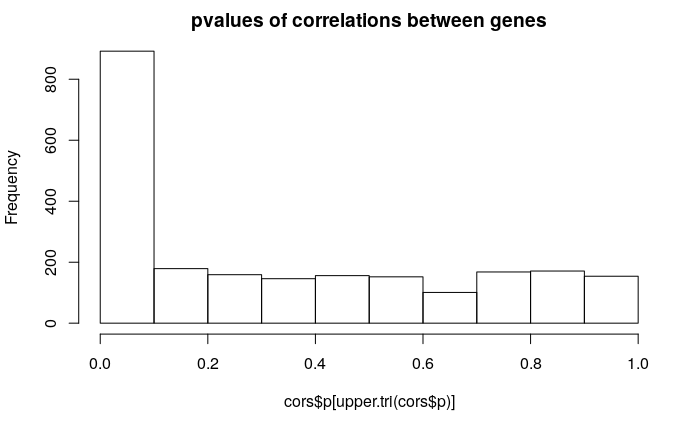

```r
cors <- psych::corr.test(totest, adjust="BH", ci=F)
# upper diagonal of p contains the adjusted pvalues
hist(cors$p[upper.tri(cors$p)], main="pvalues of correlations between genes")
```

```r
# TODO now we need to check the gene links which were selected against the ones which
# weren't...
#
```